# Practical Machine Learning - Course Project

Srini Kenthapadi

January 31, 2016

## Practical Machine Learning - Course Project

### Summary

This model is built using the classification tree and it predicts the outcome of the ‘Classe’ variable based on the various accelerometer data.

### Description

The original training data has many variables. However, for this research, only the accelerometer data is used. Among the accerelometer data, there are four variables with no data. There four variables, namely, var_total_accel_belt, var_accel_arm, var_accel_dumbbell and var_accel_forearm are removed from the trainind data. Similarly, these variable are eliminated from the testing data as well. The training data is further split in to training and testing data for building the classification tree. This model is used for predicting the ‘Classe’ outcome based on the testing data. In addition to this, the cross validation is done by spliting the data in to ten folds and the estimation of model is repeating three time.

### Pre-Processing of the Data

The training data has 160 varibles. For this research, as mentioned above, only the accelerometer data is used. Following is the code to read the data from the working directory.

```r
# Load the required packages
library(rpart)
library(caret)
# Load the training and testing data
trainingData = read.csv("pml-training.csv")
testingData = read.csv("pml-testing.csv")
```

### Distrubution of ‘Classe’ outcome

Following plot shows the distribution of ‘Classe’ among the categories of ‘A’,‘B’,‘C’,‘D’ and ‘E’.

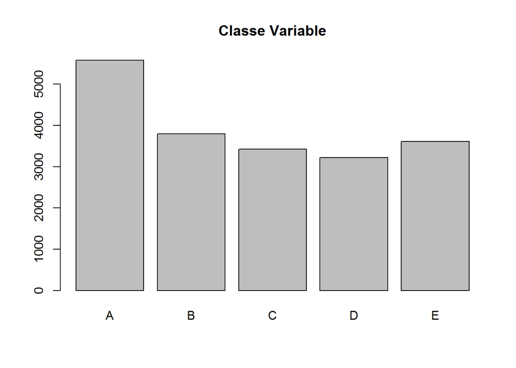

```r
# Plot the overall Classe variable
barplot(table(trainingData$classe), main="Classe Variable", names= c("A", "B", "C", "D", "E"))
```

Find the variables whose name has ‘accel’ in it. Remove the variables names var_total_accel_belt, var_accel_arm, var_accel_dumbbell and var_accel_forearm. Similarly, remove those columns from the testing data as well.

```r
#select accelerometer data from the training data
#names(trainingData)
accelTrainingData = trainingData[,grep("accel", names(trainingData), value=TRUE)]

#Remove the four columns since there are not enough data and since most of the data observation is empty
columnsToRemove = c("var_total_accel_belt", "var_accel_arm", "var_accel_dumbbell", "var_accel_forearm")
accelTrainingData = accelTrainingData[ , -which(names(accelTrainingData) %in% columnsToRemove)]
accelTrainingData = cbind(accelTrainingData, trainingData[,c("classe")])

# Split the training data in two such that one set is used as the training set and other set is
# used as the testing data
#Rename the column to 'classe'
colnames(accelTrainingData)[17] <- "classe"

inTrain = createDataPartition(y=accelTrainingData$classe, p=0.8, list = FALSE)
newTrainingData = accelTrainingData[inTrain,]
newTestingData = accelTrainingData[-inTrain,]

accelTestingData = testingData[,grep("accel", names(testingData), value=TRUE)]
accelTestingData = accelTestingData[ , -which(names(accelTestingData) %in% columnsToRemove)]
```